# Training a VAE to the MNIST dataset

We want to create a VAE which represents the images in the MNIST dataset. This serves as a practice for VAEs in theory and their relative tensorflow implementation. At the end, we will present some generated samples for comparison.

```python
import mnist, scipy
import tensorflow as tf
import numpy as np
import matplotlib.pyplot as plt
from tqdm import tnrange
```

Now we need to import the train set of the MNIST dataset. A this point, we do not care for the testset. The testset could be used, for example, to test a classifier based on the hidden vector generated by the VAE. We also do not care about the labels now, since this is an unsupervised approach.

```python
images = mnist.train_images()
images = images / 256
```

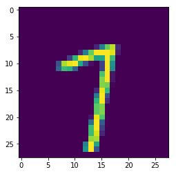

```python
plt.imshow(images[42])
plt.show()
```

## Defining the AE

Now we want to define the structure of the AE using TF. The AE has 2 main components:

- Encoder: convolutional layers
- Decoder: deconvolutional layers The specific distribution we want in a VAE is enforced by the loss we define. We want the encoder to output mean and standard deviations of a fixed number of distributions (which we want to be normal gaussians)

```python
BATCH_SIZE = 64
LATENT_SIZE = 10
LEARNING_RATE = 0.0005

tf.reset_default_graph()

# Input image
X = tf.placeholder(dtype=tf.float32, shape=(None, 28, 28))
# Reshape for convolution
X4d = tf.reshape(X, shape=(-1, 28, 28, 1))
# Dropout keep proba
keep_prob = tf.placeholder(dtype=tf.float32, shape=(), name='keep_prob')

# ENCODER GRAPH
with tf.variable_scope("encoder", reuse=None):
    conv1 = tf.layers.conv2d(X4d, filters=64, kernel_size=4, strides=2, padding='same', activation=tf.nn.relu)
    drop1 = tf.nn.dropout(conv1, keep_prob)
    conv2 = tf.layers.conv2d(drop1, filters=64, kernel_size=4, strides=2, padding='same', activation=tf.nn.relu)
    drop2 = tf.nn.dropout(conv2, keep_prob)
    conv3 = tf.layers.conv2d(drop2, filters=64, kernel_size=4, strides=1, padding='same', activation=tf.nn.relu)
    drop3 = tf.nn.dropout(conv3, keep_prob)
    flat = tf.layers.flatten(drop3)
    latent_means = tf.layers.dense(flat, units=LATENT_SIZE)
    latent_std = tf.layers.dense(flat, units=LATENT_SIZE)
    latent_noise = tf.random_normal(shape=(BATCH_SIZE, LATENT_SIZE))
    latent_vector = latent_means + tf.multiply(latent_std, latent_noise)

# DECODER GRAPH
with tf.variable_scope("decoder", reuse=None):
    deflat = tf.layers.dense(latent_vector, units=flat.shape[1])
    deflat4d = tf.reshape(deflat, shape=(-1, drop3.shape[1], drop3.shape[2], drop3.shape[3]))
    deconv1 = tf.layers.conv2d_transpose(deflat4d, filters=64, kernel_size=4, strides=1, padding='same', activation=tf.nn.relu)
    dedrop1 = tf.nn.dropout(deconv1, keep_prob)
    deconv2 = tf.layers.conv2d_transpose(dedrop1, filters=64, kernel_size=4, strides=2, padding='same', activation=tf.nn.relu)
    dedrop2 = tf.nn.dropout(deconv2, keep_prob)
    deconv3 = tf.layers.conv2d_transpose(dedrop2, filters=1, kernel_size=4, strides=2, padding='same', activation=tf.nn.relu)
    dedrop3 = tf.nn.dropout(deconv3, keep_prob)
    rebuild = tf.reshape(dedrop3, shape=(-1, 28, 28))

# Loss
reconstruction_loss = tf.reduce_sum(tf.squared_difference(rebuild, X))
reg_loss = tf.reduce_sum(-tf.log(tf.abs(latent_std)) + 0.5 * (tf.square(latent_std) + tf.square(latent_means) - 1))
complete_loss = reconstruction_loss + reg_loss

# Optimizer
optimizer = tf.train.AdamOptimizer(LEARNING_RATE).minimize(complete_loss)
```

```python
sess = tf.Session()
sess.run(tf.global_variables_initializer())
```

Once we have declared the network structure and initialized it, we can begin the training procedure.

```python
# Training
N_EPOCHS = 200
for epoch in tnrange(N_EPOCHS):
    losses = []
    for bindex in range(0, 16384, BATCH_SIZE):
        batch = images[bindex:bindex+BATCH_SIZE]
        _loss, _ = sess.run([complete_loss, optimizer], feed_dict = {X: batch, keep_prob:0.8})
        losses.append(_loss)
    print("Epoch", epoch, "- Mean Loss:", np.mean(losses))
```

```
Epoch 0 - Mean Loss: 4017.6729
Epoch 1 - Mean Loss: 3410.108
Epoch 2 - Mean Loss: 3176.6355
Epoch 3 - Mean Loss: 3097.524
Epoch 4 - Mean Loss: 3038.7773
Epoch 5 - Mean Loss: 3002.3665
Epoch 6 - Mean Loss: 2975.906
Epoch 7 - Mean Loss: 2953.0562
Epoch 8 - Mean Loss: 2942.2664
Epoch 9 - Mean Loss: 2925.2866
Epoch 10 - Mean Loss: 2916.168
Epoch 11 - Mean Loss: 2899.7114
Epoch 12 - Mean Loss: 2895.1865
Epoch 13 - Mean Loss: 2887.9731
Epoch 14 - Mean Loss: 2882.2817
Epoch 15 - Mean Loss: 2875.535
Epoch 16 - Mean Loss: 2869.2195
Epoch 17 - Mean Loss: 2865.0186
Epoch 18 - Mean Loss: 2863.524
Epoch 19 - Mean Loss: 2854.935
Epoch 20 - Mean Loss: 2857.8525
Epoch 21 - Mean Loss: 2851.08
Epoch 22 - Mean Loss: 2847.4666
Epoch 23 - Mean Loss: 2842.0623
Epoch 24 - Mean Loss: 2836.3596
Epoch 25 - Mean Loss: 2830.0918
Epoch 26 - Mean Loss: 2835.3818
Epoch 27 - Mean Loss: 2833.2097
Epoch 28 - Mean Loss: 2833.1665
Epoch 29 - Mean Loss: 2825.708
Epoch 30 - Mean Loss: 2822.983
Epoch 31 - Mean Loss: 2823.1714
Epoch 32 - Mean Loss: 2821.5298
Epoch 33 - Mean Loss: 2821.8838
Epoch 34 - Mean Loss: 2816.5928
Epoch 35 - Mean Loss: 2819.9436
Epoch 36 - Mean Loss: 2814.809
Epoch 37 - Mean Loss: 2814.0237
Epoch 38 - Mean Loss: 2812.9954
Epoch 39 - Mean Loss: 2811.15
```

[output cut: 145 more lines]

```
Epoch 185 - Mean Loss: 2749.9038
Epoch 186 - Mean Loss: 2749.2349
Epoch 187 - Mean Loss: 2746.2505
Epoch 188 - Mean Loss: 2749.8474
Epoch 189 - Mean Loss: 2749.19
Epoch 190 - Mean Loss: 2748.2397
Epoch 191 - Mean Loss: 2747.2876
Epoch 192 - Mean Loss: 2749.2827
Epoch 193 - Mean Loss: 2748.065
Epoch 194 - Mean Loss: 2748.857
Epoch 195 - Mean Loss: 2750.876
Epoch 196 - Mean Loss: 2749.3623
Epoch 197 - Mean Loss: 2747.518
Epoch 198 - Mean Loss: 2751.2227
Epoch 199 - Mean Loss: 2749.5847
```

Now we can generate random samples by feeding a noise vector, distributed as a standard normal.

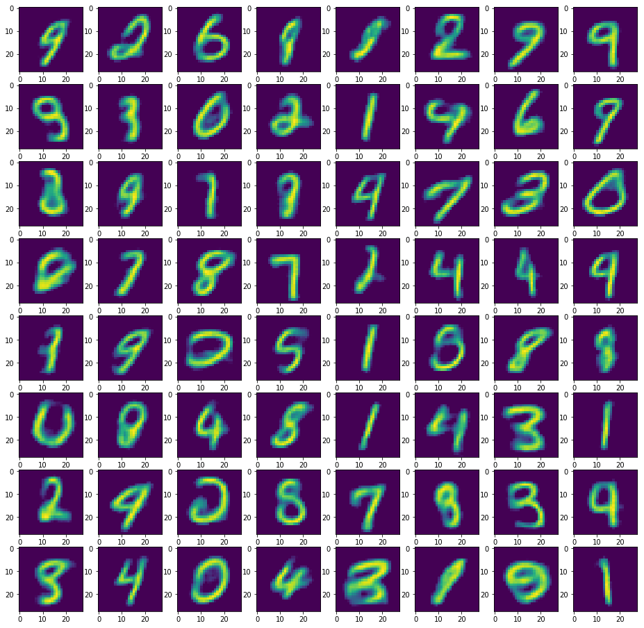

```python
R, C = 8, 8
z = np.random.standard_normal((R*C, LATENT_SIZE))
reco = sess.run(rebuild, feed_dict = {latent_vector: z, keep_prob:1.0})
f, ax = plt.subplots(R, C, figsize=(16,16))
for r in range(R):
    for c in range(C):
        ax[r,c].imshow(reco[r*8 + c])
plt.show()
```

The results are quite good, keeping also in mind that this was not tuned and serves only as a proof of concept and bug-testing.